# Lab 7: Logistic Regression

MATH 4780 / MSSC 5780 Regression Analysis

Author

Mehdi Maadooliat

**NoteCourse data**

This lab uses objects in `regression_datasets.rda`. Put the `.qmd` file and `regression_datasets.rda` in the same folder before rendering or working through the lab.

## Learning goals

Fit and interpret a logistic regression model, work with probabilities, log-odds, and odds ratios, assess model fit, and use fitted probabilities for classification.

```r
library(ggplot2)
library(dplyr)
library(broom)
```

## 1. Fastener data

The `fastener` dataset from the 2026 logistic-regression slides contains:

- `load`: applied load,
- `m`: number of fasteners tested,
- `y`: number with the event of interest.

```r
fastener
```

```
   load   m  y
1  2500  50 10
2  2700  70 17
3  2900 100 30
4  3100  60 21
5  3300  40 18
6  3500  85 43
7  3700  90 54
8  3900  50 33
9  4100  80 60
10 4300  65 51
```

Create the observed proportion.

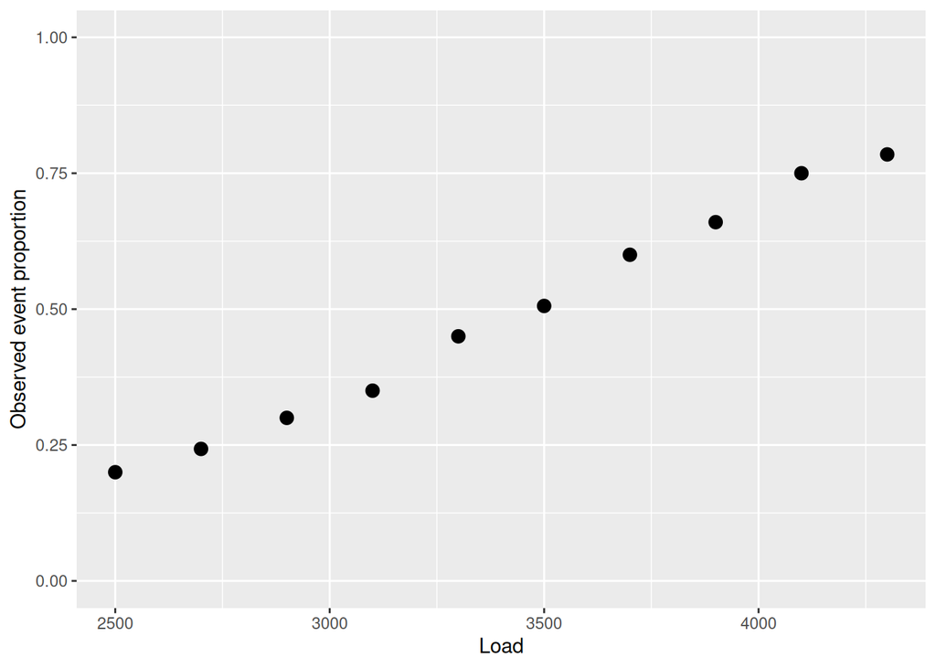

```r
fastener <- fastener |>
  mutate(prop = y / m)

ggplot(fastener, aes(load, prop)) +
  geom_point(size = 3) +
  labs(x = "Load", y = "Observed event proportion") +
  coord_cartesian(ylim = c(0, 1))
```

Why would an ordinary linear regression of `prop` on `load` be problematic?

## 2. Fit a grouped-binomial logistic model

For grouped binomial data, use the numbers of successes and failures.

```r
fit_logit <- glm(
  cbind(y, m - y) ~ load,
  family = binomial(link = "logit"),
  data = fastener
)

summary(fit_logit)
```

```
Call:
glm(formula = cbind(y, m - y) ~ load, family = binomial(link = "logit"),
    data = fastener)

Coefficients:
             Estimate Std. Error z value Pr(>|z|)
(Intercept) -5.339712   0.545693   -9.79   <2e-16 ***
load         0.001548   0.000158    9.83   <2e-16 ***
---
Signif. codes:  0 '***' 0.001 '**' 0.01 '*' 0.05 '.' 0.1 ' ' 1

(Dispersion parameter for binomial family taken to be 1)

    Null deviance: 112.83207  on 9  degrees of freedom
Residual deviance:   0.37192  on 8  degrees of freedom
AIC: 49.09

Number of Fisher Scoring iterations: 3
```

## 3. Interpret the coefficients

```r
broom::tidy(fit_logit, conf.int = TRUE)
```

```
# A tibble: 2 × 7
  term        estimate std.error statistic  p.value conf.low conf.high
  <chr>          <dbl>     <dbl>     <dbl>    <dbl>    <dbl>     <dbl>
1 (Intercept) -5.34     0.546        -9.79 1.30e-22 -6.43     -4.29
2 load         0.00155  0.000158      9.83 8.45e-23  0.00125   0.00186
```

Exponentiating a coefficient converts a change in log-odds into an **odds ratio**.

```r
exp(coef(fit_logit))
```

```
(Intercept)        load
     0.0048      1.0015
```

```r
exp(confint.default(fit_logit))
```

```
              2.5 % 97.5 %
(Intercept) 0.00165  0.014
load        1.00124  1.002
```

## 4. Fitted probabilities

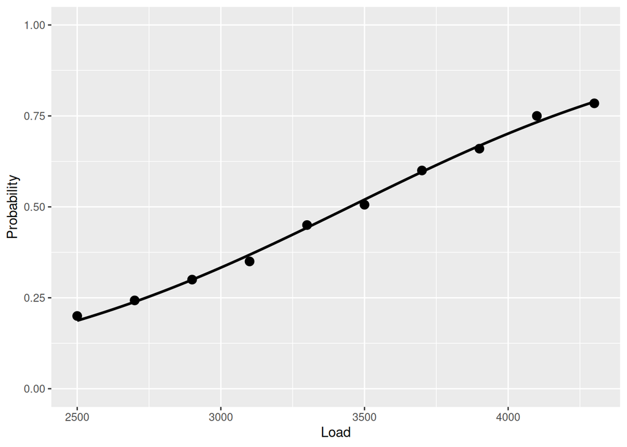

```r
grid <- data.frame(
  load = seq(min(fastener$load), max(fastener$load), length.out = 200)
)

grid$prob <- predict(fit_logit, newdata = grid, type = "response")

ggplot(fastener, aes(load, prop)) +
  geom_point(size = 3) +
  geom_line(data = grid, aes(load, prob), linewidth = 1) +
  labs(x = "Load", y = "Probability") +
  coord_cartesian(ylim = c(0, 1))
```

At approximately what load does the fitted event probability cross 0.5?

You can solve this directly from the fitted coefficients.

```r
b <- coef(fit_logit)
load_at_half <- -b[1] / b[2]
load_at_half
```

```
(Intercept)
       3448
```

## 5. Predictions on three scales

```r
new_load <- data.frame(load = c(
  min(fastener$load),
  median(fastener$load),
  max(fastener$load)
))

data.frame(
  new_load,
  linear_predictor = predict(fit_logit, newdata = new_load, type = "link"),
  probability = predict(fit_logit, newdata = new_load, type = "response")
)
```

```
  load linear_predictor probability
1 2500           -1.469       0.187
2 3400           -0.075       0.481
3 4300            1.319       0.789
```

Explain the distinction among probability, odds, and log-odds.

## 6. Likelihood-based model comparison

Compare the logistic model with an intercept-only model.

```r
fit_null <- glm(
  cbind(y, m - y) ~ 1,
  family = binomial,
  data = fastener
)

anova(fit_null, fit_logit, test = "Chisq")
```

```
Analysis of Deviance Table

Model 1: cbind(y, m - y) ~ 1
Model 2: cbind(y, m - y) ~ load
  Resid. Df Resid. Dev Df Deviance Pr(>Chi)
1         9      112.8
2         8        0.4  1      112   <2e-16 ***
---
Signif. codes:  0 '***' 0.001 '**' 0.01 '*' 0.05 '.' 0.1 ' ' 1
```

What hypothesis is being tested by this likelihood-ratio comparison?

## 7. Classification as a decision rule

A 0.5 probability threshold is common, but it is not universally optimal.

Expand the grouped counts only for this illustration.

```r
fastener_binary <- fastener |>
  rowwise() |>
  reframe(
    load = load,
    outcome = c(rep(1, y), rep(0, m - y))
  ) |>
  ungroup() |>
  mutate(
    prob = predict(fit_logit, newdata = data.frame(load = load),
                   type = "response"),
    class = if_else(prob >= 0.5, 1, 0)
  )

with(fastener_binary, table(observed = outcome, predicted = class))
```

```
        predicted
observed   0   1
       0 224 129
       1  96 241
```

```r
mean(fastener_binary$outcome == fastener_binary$class)
```

```
[1] 0.674
```

Why might a threshold other than 0.5 be preferable in an application where false positives and false negatives have different consequences?

## 8. Extension: individual-level logistic regression with Whickham data

The grouped `fastener` example is useful because it matches the current course slides. The `Whickham` data provide a complementary example in which each row is an individual and one predictor is categorical.

```r
names(Whickham)
```

```
[1] "outcome" "smoker"  "age"
```

```r
head(Whickham)
```

```
  outcome smoker age
1   Alive    Yes  23
2   Alive    Yes  18
3    Dead    Yes  71
4   Alive     No  67
5   Alive     No  64
6   Alive    Yes  38
```

```r
table(Whickham$outcome, Whickham$smoker)
```

```
         No Yes
  Alive 502 443
  Dead  230 139
```

Create a binary response equal to 1 for an individual who was alive at the follow-up.

```r
whickham <- Whickham |>
  mutate(
    isAlive = as.integer(outcome == "Alive"),
    smoker = factor(smoker)
  )
```

Fit a model using age and smoking status.

```r
fit_whickham <- glm(
  isAlive ~ age + smoker,
  family = binomial,
  data = whickham
)

summary(fit_whickham)
```

```
Call:
glm(formula = isAlive ~ age + smoker, family = binomial, data = whickham)

Coefficients:
            Estimate Std. Error z value Pr(>|z|)
(Intercept)  7.59922    0.44123   17.22   <2e-16 ***
age         -0.12368    0.00718  -17.23   <2e-16 ***
smokerYes   -0.20470    0.16842   -1.22     0.22
---
Signif. codes:  0 '***' 0.001 '**' 0.01 '*' 0.05 '.' 0.1 ' ' 1

(Dispersion parameter for binomial family taken to be 1)

    Null deviance: 1560.32  on 1313  degrees of freedom
Residual deviance:  945.02  on 1311  degrees of freedom
AIC: 951

Number of Fisher Scoring iterations: 6
```

Display coefficient estimates as odds ratios.

```r
broom::tidy(fit_whickham, conf.int = TRUE, exponentiate = TRUE)
```

```
# A tibble: 3 × 7
  term        estimate std.error statistic  p.value conf.low conf.high
  <chr>          <dbl>     <dbl>     <dbl>    <dbl>    <dbl>     <dbl>
1 (Intercept) 1997.      0.441       17.2  1.79e-66  870.     4916.
2 age            0.884   0.00718    -17.2  1.49e-66    0.871     0.896
3 smokerYes      0.815   0.168       -1.22 2.24e- 1    0.585     1.13
```

1. Interpret the odds ratio associated with age.
2. Interpret the smoking-status odds ratio while holding age fixed.
3. Why can a marginal comparison between smokers and nonsmokers differ from the age-adjusted logistic-regression comparison?

Visualize the fitted probabilities by smoking status.

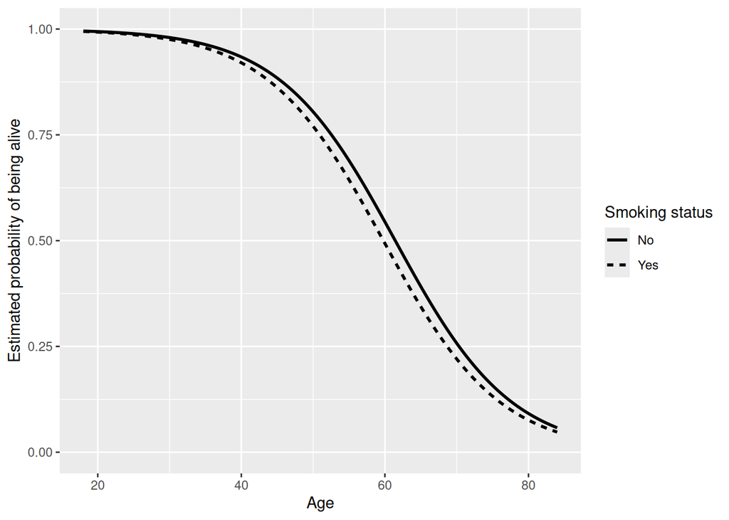

```r
whickham_grid <- expand.grid(
  age = seq(min(whickham$age), max(whickham$age), length.out = 200),
  smoker = levels(whickham$smoker)
)

whickham_grid$prob <- predict(
  fit_whickham,
  newdata = whickham_grid,
  type = "response"
)

ggplot(whickham_grid, aes(age, prob, linetype = smoker)) +
  geom_line(linewidth = 1) +
  labs(
    x = "Age",
    y = "Estimated probability of being alive",
    linetype = "Smoking status"
  ) +
  coord_cartesian(ylim = c(0, 1))
```

### Does the age effect differ by smoking status?

```r
fit_whickham_int <- glm(
  isAlive ~ age * smoker,
  family = binomial,
  data = whickham
)

anova(fit_whickham, fit_whickham_int, test = "Chisq")
```

```
Analysis of Deviance Table

Model 1: isAlive ~ age + smoker
Model 2: isAlive ~ age * smoker
  Resid. Df Resid. Dev Df Deviance Pr(>Chi)
1      1311        945
2      1310        943  1     2.34     0.13
```

What does the likelihood-ratio test say about adding the age-by-smoking interaction? Distinguish statistical evidence from substantive importance.

**TipWhy use both logistic examples?**

The `fastener` data illustrate **grouped binomial** logistic regression, while `Whickham` illustrates **individual binary outcomes**, adjustment for a categorical predictor, odds ratios, and possible interaction. Together they show that the same logistic-regression framework handles both data structures.

## Takeaway

Logistic regression models a linear relationship on the **log-odds** scale, which guarantees fitted probabilities between 0 and 1. Coefficients are most naturally interpreted through odds ratios, while classification requires an additional decision threshold.